# Stock Price Prediction with ARIMA

Time Series Forecasting means analyzing and modeling time-series data to make future decisions. Some of the applications of Time Series Forecasting are weather forecasting, sales forecasting, business forecasting, stock price forecasting, etc. The ARIMA model is a popular statistical technique used for Time Series Forecasting. If you want to learn Time Series Forecasting with ARIMA, this article is for you. In this article, I will take you through the task of Time Series Forecasting with ARIMA using the Python programming language.

```python
pip install yfinance
```

```python
import pandas as pd
import yfinance as yf
import datetime
from datetime import date, timedelta
today = date.today()

d1 = today.strftime("%Y-%m-%d")
end_date = d1
d2 = date.today() - timedelta(days=365)
d2 = d2.strftime("%Y-%m-%d")
start_date = d2

data = yf.download('GOOG',
                      start=start_date,
                      end=end_date,
                      progress=False)
data["Date"] = data.index
data = data[["Date", "Open", "High", "Low", "Close", "Adj Close", "Volume"]]
data.reset_index(drop=True, inplace=True)
print(data.tail())
```

```
          Date        Open        High         Low       Close   Adj Close  \
245 2023-08-21  127.849998  129.259995  127.160004  128.929993  128.929993
246 2023-08-22  129.130005  130.949997  128.925003  129.690002  129.690002
247 2023-08-23  130.850006  134.070007  130.509995  133.210007  133.210007
248 2023-08-24  134.727005  134.970001  130.300003  130.419998  130.419998
249 2023-08-25  130.139999  131.399994  128.039993  130.690002  130.690002

       Volume
245  21851100
246  15569400
247  26497000
248  18680400
249  20671000
```

## What is ARIMA?

ARIMA stands for Autoregressive Integrated Moving Average. It is an algorithm used for forecasting Time Series Data. ARIMA models have three parameters like ARIMA(p, d, q). Here p, d, and q are defined as:

1. p is the number of lagged values that need to be added or subtracted from the values (label column). It captures the autoregressive part of ARIMA.
2. d represents the number of times the data needs to differentiate to produce a stationary signal. If it’s stationary data, the value of d should be 0, and if it’s seasonal data, the value of d should be 1. d captures the integrated part of ARIMA.
3. q is the number of lagged values for the error term added or subtracted from the values (label column). It captures the moving average part of ARIMA.

I hope you have now understood the ARIMA model. In the section below, I will take you through the task of Time Series Forecasting of stock prices with ARIMA using the Python programming language.

## Time Series Forecasting with ARIMA

Now let’s start with the task of Time Series Forecasting with ARIMA. I will first collect Google stock price data using the Yahoo Finance API. If you have never used Yahoo Finance API, you can learn more about it here.

We only need the date and close prices columns for the rest of the task, so let’s select both the columns and move further:

```python
data = data[["Date", "Close"]]
print(data.head())
```

```
        Date       Close
0 2022-08-29  110.339996
1 2022-08-30  109.910004
2 2022-08-31  109.150002
3 2022-09-01  110.550003
4 2022-09-02  108.680000
```

Now let’s visualize the close prices of Google before moving forward:

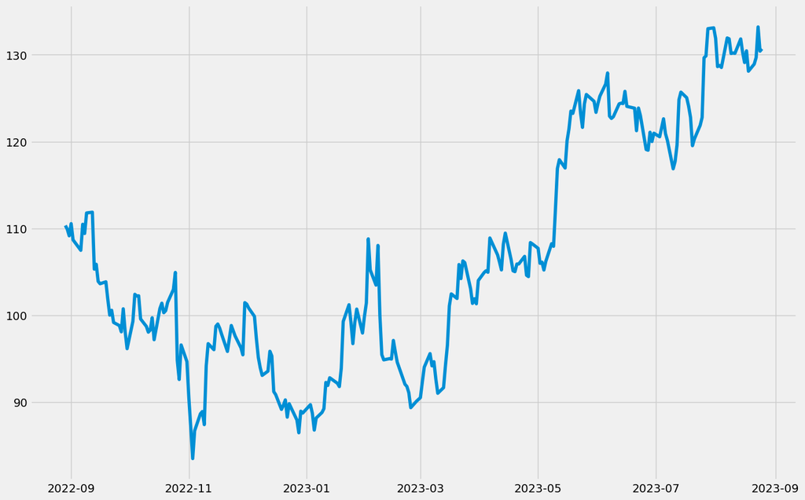

```python
import matplotlib.pyplot as plt
plt.style.use('fivethirtyeight')
plt.figure(figsize=(15, 10))
plt.plot(data["Date"], data["Close"])
```

## Using ARIMA for Time Series Forecasting

Before using the ARIMA model, we have to figure out whether our data is stationary or seasonal. The data visualization graph about the closing stock prices above shows that our dataset is not stationary. To check whether our dataset is stationary or seasonal properly, we can use the seasonal decomposition method that splits the time series data into trend, seasonal, and residuals for a better understanding of the time series data:

```python
# from statsmodels.tsa.seasonal import seasonal_decompose
# import pandas as pd
# import matplotlib.pyplot as plt
# result = seasonal_decompose(data["Close"], model='multiplicative', freq=30)
# # fig = plt.figure()
# # fig = result.plot()
# # fig.set_size_inches(15, 10)
```

[output not shown]

To use ARIMA or SARIMA, we need to find the p, d, and q values. We can find the value of p by plotting the autocorrelation of the Close column and the value of q by plotting the partial autocorrelation plot. The value of d is either 0 or 1. If the data is stationary, we should use 0, and if the data is seasonal, we should use 1. As our data is seasonal, we should use 1 as the d value.

Now here’s how to find the value of p:

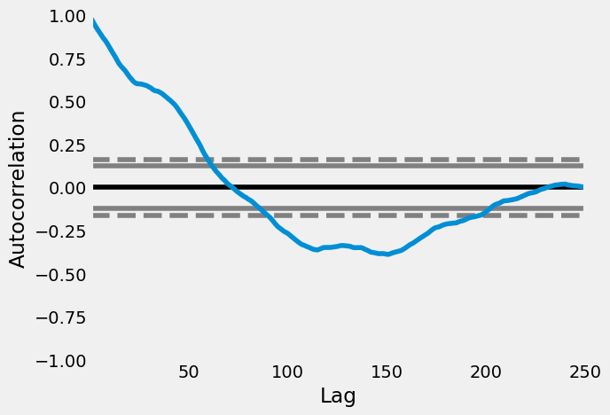

```python
pd.plotting.autocorrelation_plot(data["Close"])
```

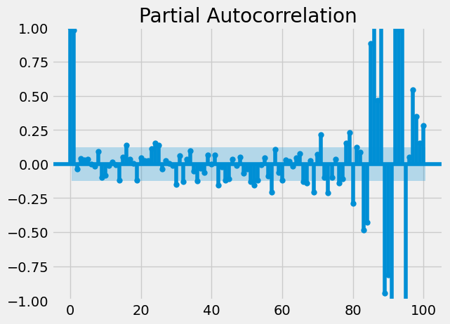

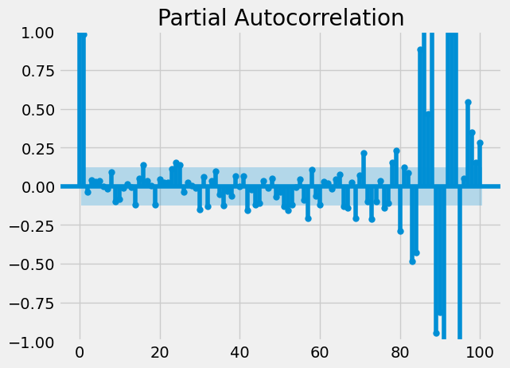

```python
from statsmodels.graphics.tsaplots import plot_pacf
plot_pacf(data["Close"], lags = 100)
```

```python
p, d, q = 5, 1, 2
from statsmodels.tsa.arima.model import ARIMA
model = ARIMA(data["Close"], order=(p,d,q))
# Fit the model
fitted = model.fit()
# Set the display option
fitted.params['disp'] = -1
# Print the summary
print(fitted.summary())
```

```
                               SARIMAX Results
==============================================================================
Dep. Variable:                  Close   No. Observations:                  250
Model:                 ARIMA(5, 1, 2)   Log Likelihood                -557.644
Date:                Sun, 27 Aug 2023   AIC                           1131.287
Time:                        09:54:24   BIC                           1159.427
Sample:                             0   HQIC                          1142.614
                                - 250
Covariance Type:                  opg
==============================================================================
                 coef    std err          z      P>|z|      [0.025      0.975]
------------------------------------------------------------------------------
ar.L1          0.3095      4.628      0.067      0.947      -8.761       9.379
ar.L2          0.1131      1.154      0.098      0.922      -2.149       2.375
ar.L3          0.0452      0.575      0.079      0.937      -1.081       1.171
ar.L4         -0.0316      0.188     -0.168      0.867      -0.401       0.337
ar.L5          0.0142      0.274      0.052      0.959      -0.523       0.551
ma.L1         -0.2687      4.631     -0.058      0.954      -9.345       8.808
ma.L2         -0.2464      1.130     -0.218      0.827      -2.461       1.969
sigma2         5.1603      0.332     15.549      0.000       4.510       5.811
===================================================================================
Ljung-Box (L1) (Q):                   0.00   Jarque-Bera (JB):                49.88
Prob(Q):                              0.99   Prob(JB):                         0.00
Heteroskedasticity (H):               0.76   Skew:                            -0.06
Prob(H) (two-sided):                  0.21   Kurtosis:                         5.19
===================================================================================

Warnings:
[1] Covariance matrix calculated using the outer product of gradients (complex-step).
```

Here’s how to predict the values using the ARIMA model:

```python
predictions = fitted.predict()
print(predictions)
```

```
0        0.000000
1      110.340016
2      109.895576
3      109.171002
4      110.684484
          ...
245    127.920925
246    129.318273
247    129.504132
248    133.428385
249    129.824894
Name: predicted_mean, Length: 250, dtype: float64
```

```python
import statsmodels.api as sm
import warnings
model=sm.tsa.statespace.SARIMAX(data['Close'],
                                order=(p, d, q),
                                seasonal_order=(p, d, q, 12))
model=model.fit()
print(model.summary())
```

```
                                     SARIMAX Results
==========================================================================================
Dep. Variable:                              Close   No. Observations:                  250
Model:             SARIMAX(5, 1, 2)x(5, 1, 2, 12)   Log Likelihood                -544.432
Date:                            Sun, 27 Aug 2023   AIC                           1118.865
Time:                                    09:55:02   BIC                           1170.886
Sample:                                         0   HQIC                          1139.832
                                            - 250
Covariance Type:                              opg
==============================================================================
                 coef    std err          z      P>|z|      [0.025      0.975]
------------------------------------------------------------------------------
ar.L1          0.2918      3.373      0.087      0.931      -6.319       6.903
ar.L2          0.0687      0.819      0.084      0.933      -1.537       1.675
ar.L3          0.0614      0.442      0.139      0.890      -0.806       0.929
ar.L4         -0.0828      0.208     -0.398      0.690      -0.490       0.324
ar.L5          0.0197      0.347      0.057      0.955      -0.660       0.700
ma.L1         -0.2386      3.373     -0.071      0.944      -6.849       6.372
ma.L2         -0.2073      0.744     -0.279      0.781      -1.666       1.251
ar.S.L12      -0.4366      1.064     -0.410      0.682      -2.522       1.649
ar.S.L24      -0.2336      0.118     -1.984      0.047      -0.464      -0.003
ar.S.L36      -0.1349      0.205     -0.658      0.511      -0.537       0.267
ar.S.L48   -3.128e-05      0.120     -0.000      1.000      -0.234       0.234
ar.S.L60      -0.0703      0.135     -0.521      0.603      -0.335       0.194
ma.S.L12      -0.5909      0.968     -0.610      0.542      -2.489       1.307
ma.S.L24      -0.3758      1.158     -0.325      0.746      -2.645       1.893
sigma2         4.9007      1.653      2.965      0.003       1.661       8.140
===================================================================================
Ljung-Box (L1) (Q):                   0.09   Jarque-Bera (JB):                16.80
Prob(Q):                              0.77   Prob(JB):                         0.00
Heteroskedasticity (H):               0.82   Skew:                             0.09
Prob(H) (two-sided):                  0.39   Kurtosis:                         4.29
===================================================================================

Warnings:
[1] Covariance matrix calculated using the outer product of gradients (complex-step).
```

```python
predictions = model.predict(len(data), len(data)+10)
print(predictions)
```

```
250    130.688076
251    128.568352
252    129.593241
253    129.243517
254    128.853768
255    129.823838
256    130.049549
257    129.551225
258    129.651453
259    130.122103
260    131.155726
Name: predicted_mean, dtype: float64
```

Here’s how you can plot the predictions:

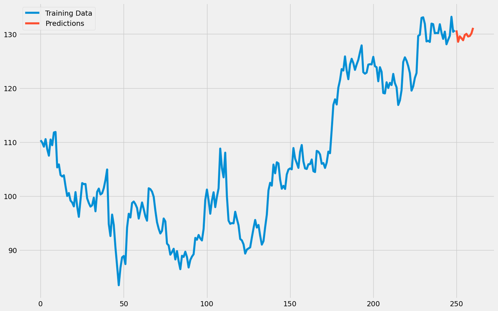

```python
data["Close"].plot(legend=True, label="Training Data", figsize=(15, 10))
predictions.plot(legend=True, label="Predictions")
```

So this is how you can use ARIMA or SARIMA models for Time Series Forecasting using Python.

## Summary

ARIMA stands for Autoregressive Integrated Moving Average. It is an algorithm used for forecasting Time Series Data. If the data is stationary, we need to use ARIMA, if the data is seasonal, we need to use Seasonal ARIMA (SARIMA). I hope you liked this article about Time Series Forecasting with ARIMA using Python. Feel free to ask valuable questions in the comments section below.